# "Nappy Detective - Pieluszkowy Detektyw" - aplikacja do wykrywania nieprawidłowego zabarwienia niemowlęcych stolców

To innowacyjna aplikacja tworzona z myślą o wczesnym wykrywaniu chorób związanych z nieprawidłowym kolorem stolca niemowląt,  
takich jak atrezja zewnątrzwątrobowych dróg żółciowych. Dzięki zaawansowanej analizie zdjęć, aplikacja umożliwi szybkie rozpoznanie potencjalnych  
nieprawidłowości, co może pomóc w wczesnym rozpoczęciu leczenia operacyjnego, tak jak wykazano w badaniach przeprowadzonych w krajach  
takich jak Tajwan, Japonia czy Kanada.

Inspiracją dla aplikacji była inicjatywa PoopMD stworzona przez John Hopkins University, która pomogła znacząco skrócić czas diagnozowania tej choroby.  
Współwystępowanie żółtaczki i odbarwionych stolców stanowi kluczowy sygnał do rozpoczęcia diagnostyki, a NappyDetective będzie  
narzędziem wspierającym w tym procesie. https://pubmed.ncbi.nlm.nih.gov/26221719/

## Specyfikacja / Specs

- Użytkownik wybiera zdjęcie ze swojego urządzenia i udostępnia aplikacji
- Aplikacja analizuje i klasyfikuje zdjęcie, odrzuca jeżeli jest nieadekwatne
- Aplikacja podaje wynik analizy i doradza dalsze postępowanie
- W przypadkach wątpliwych aplikacja zaleca i umożliwia przesłanie zdjęcia do ośrodka specjalistycznego (email)
- Aplikacja prosi o przesłania zdjęcia do bazy danych w celu zwiększenia skuteczności klasyfikacji
- Aplikacja zawiera treści edukacyjne
- W aplikacji dostępny jest regulamin użytkowania
- Aplikacja umożliwia przekazanie twórcom donacji ("postaw kawę")
- Aplikacja może zawierać reklamy

## Architektura

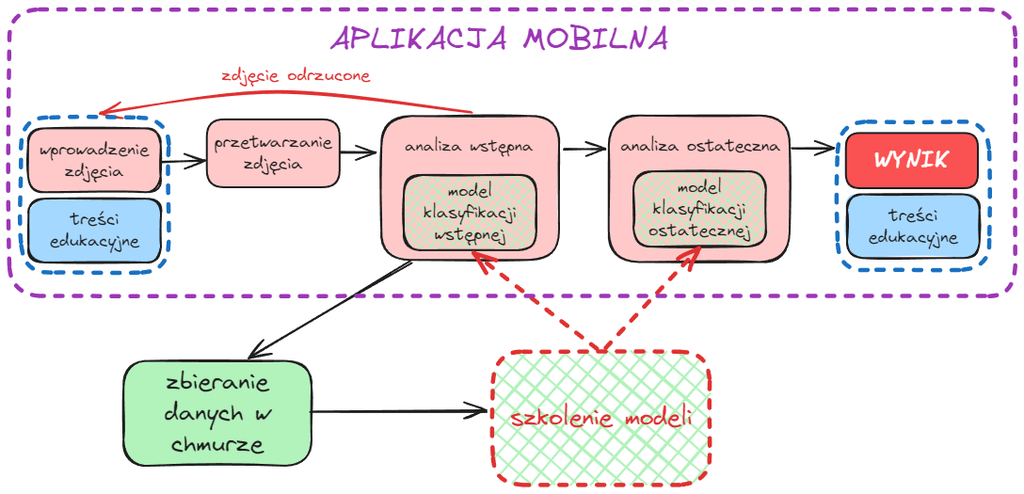

## Plan / Taski

Zadania ogólne:

1. Zbieranie danych
2. Przygotowanie treści informacyjnych i edukacyjnych
3. Przygotowanie regulaminu uzytkowania
4. Przygotowanie tutorialu
5. Przygotowanie demo
6. Oficjalne testy
7. Analiza wyników testu
8. Publikacja wyników

Aplikacja:

- v1 - wczytywanie zdjęcia i wyświetlanie na ekranie
- v2 - przesyłanie zdjęcia do bazy danych (Cloudinary) lub przesyłanie przez email pod podany adres
- v3 - opracowanie interakcji z użytkownikiem
- v4 - wyświetlanie treści informacyjnych i edukacyjnych
- v5 - wyświetlanie regulaminu użytkowania
- v6 - wdrożenie modelu klasyfikacyjnego
- v7 - dopracowanie interfejsu
- v8 - testowanie i optymalizacja
- v9 - wdrożenie
- v10 - internacjonalizacja

Model:

1. Przygotowanie zdjęć (poszukiwanie kupy, decydowanie, czy to kupa, przetwarzanie zdjęć)
2. Wybór i szkolenie modeli klasyfikacji
3. Ocena modelu i walidacja
4. Przygotowanie monitorowania wyników
5. Przygotowanie do aktualizacji

## Zależności

- Dart 🎯
  - `Flutter` - do budowy aplikacji.
  - `image_picker` - do pobierania zdjęć.
  - `permission_handler` - do uzyskania zgody na dostęp do zdjęć.
  - `device_info_plus` - do sprawdzania wersji urządzenia.
  - `tflite_flutter` - do uruchamiania modeli TensorFlow Lite w aplikacji mobilnej.
  - `image` - do przekształcania zdjęć do modelu.
  - `http` - do przesyłania zdjęć do chmury.
  - `flutter_localizations`, `intl` - do obsługi internacjonalizacji
- Python 🐍
  - `pandas` - do przygotowania modeli klasyfikacji.
  - `TensorFlow` - do trenowania i wdrażania modeli uczenia maszynowego.
  - `scikit-learn` - do analizy i przetwarzania danych.
  - `numpy` - do operacji na danych numerycznych.
  - `ResNet` - do trenowania ostatecznego modelu.